# Experiment 2 — Pairwise Evaluation Report

**GPT-4o-as-Judge** post-hoc evaluation over all **5,760 session pairs** from Exp 2. Each pair = (R0: generic RAG, R1: FSLSM-personalized) response to the same question from the same virtual student agent.

**Judge task:** Given the agent's FSLSM profile and the student question, select the more pedagogically appropriate response.

**Key result:** R1 wins **94.1%** of decisive pairs (p < 2.2e-16, all 16 FSLSM profiles).

```python
%matplotlib inline
import json
import sys
from pathlib import Path

import numpy as np
import pandas as pd
import matplotlib.pyplot as plt
import matplotlib.patches as mpatches
import seaborn as sns
from scipy import stats

# ── Paths (relative to notebook location) ──────────────────────────────────
RESULTS_DIR = Path("results")
PAIRWISE_DIR = RESULTS_DIR / "pairwise"
FIG_DIR = PAIRWISE_DIR / "figures"
FIG_DIR.mkdir(parents=True, exist_ok=True)

# ── Theme ───────────────────────────────────────────────────────────────────
plt.rcParams.update({
    "figure.dpi": 150,
    "axes.spines.top": False,
    "axes.spines.right": False,
    "font.size": 11,
})
C_R1  = "#2196F3"   # blue  — R1 personalized
C_R0  = "#FF9800"   # orange — R0 generic

# ── Load data ───────────────────────────────────────────────────────────────
verdicts  = pd.read_csv(PAIRWISE_DIR / "final_verdicts.csv")
prof_df   = pd.read_csv(PAIRWISE_DIR / "summary_by_profile.csv")
with open(PAIRWISE_DIR / "summary_overall.json") as f:
    overall = json.load(f)
with open(PAIRWISE_DIR / "convergence_check.json") as f:
    convergence = json.load(f)

# Derived scalars
n_total  = overall["n_total"]
n_r1     = overall["n_r1_win"]
n_r0     = overall["n_r0_win"]
n_tie    = overall["n_tie"]
win_rate = overall["win_rate_r1"]
ci_lo    = overall["win_rate_r1_ci_lo"]
ci_hi    = overall["win_rate_r1_ci_hi"]
p_val    = overall["binomial_p_value"]

print(f"Sessions : {n_total:,}")
print(f"R1_WIN   : {n_r1:,} ({n_r1/n_total*100:.1f}%)")
print(f"R0_WIN   : {n_r0:,} ({n_r0/n_total*100:.1f}%)")
print(f"TIE      : {n_tie:,}")
print(f"Win rate : {win_rate:.3f}  95% CI [{ci_lo:.3f}, {ci_hi:.3f}]  p < 2.2e-16")
```

```
Sessions : 5,760
R1_WIN   : 5,419 (94.1%)
R0_WIN   : 341 (5.9%)
TIE      : 0
Win rate : 0.941  95% CI [0.934, 0.947]  p < 2.2e-16
```

## 1. Overall Win Rate

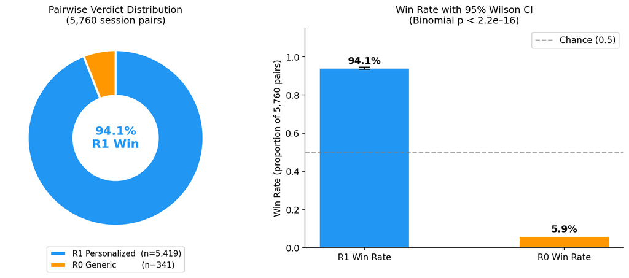

```python
fig, axes = plt.subplots(1, 2, figsize=(12, 5))

# ── Left: donut ──────────────────────────────────────────────────────────────
ax = axes[0]
wedge_props = dict(width=0.52, edgecolor="white", linewidth=2.5)
wedges, _ = ax.pie(
    [n_r1, n_r0],
    colors=[C_R1, C_R0],
    wedgeprops=wedge_props,
    startangle=90,
    counterclock=False,
)
ax.text(0, 0, f"{win_rate*100:.1f}%\nR1 Win", ha="center", va="center",
        fontsize=15, fontweight="bold", color=C_R1)
ax.legend(
    wedges,
    [f"R1 Personalized  (n={n_r1:,})", f"R0 Generic          (n={n_r0:,})"],
    loc="lower center", bbox_to_anchor=(0.5, -0.13), fontsize=10,
)
ax.set_title("Pairwise Verdict Distribution\n(5,760 session pairs)", fontsize=12)

# ── Right: win-rate bar + CI ─────────────────────────────────────────────────
ax2 = axes[1]
r0_wr = n_r0 / n_total
bars = ax2.bar(["R1 Win Rate", "R0 Win Rate"], [win_rate, r0_wr],
               color=[C_R1, C_R0], width=0.45, edgecolor="white")
ax2.errorbar(0, win_rate,
             yerr=[[win_rate - ci_lo], [ci_hi - win_rate]],
             fmt="none", color="black", capsize=7, linewidth=2)
for bar, val in zip(bars, [win_rate, r0_wr]):
    ax2.text(bar.get_x() + bar.get_width() / 2, val + 0.012,
             f"{val*100:.1f}%", ha="center", va="bottom", fontweight="bold", fontsize=12)
ax2.axhline(0.5, color="gray", linestyle="--", alpha=0.6, label="Chance (0.5)")
ax2.set_ylim(0, 1.15)
ax2.set_ylabel("Win Rate (proportion of 5,760 pairs)")
ax2.set_title("Win Rate with 95% Wilson CI\n(Binomial p < 2.2e–16)", fontsize=12)
ax2.legend()

plt.tight_layout()
plt.savefig(FIG_DIR / "overall_win_rate.png", dpi=150, bbox_inches="tight")
plt.show()
```

## 2. Win Rate by FSLSM Profile

All 16 profiles significant at Bonferroni-corrected α = 0.003 (*** markers). Error bars = 95% Wilson CI.

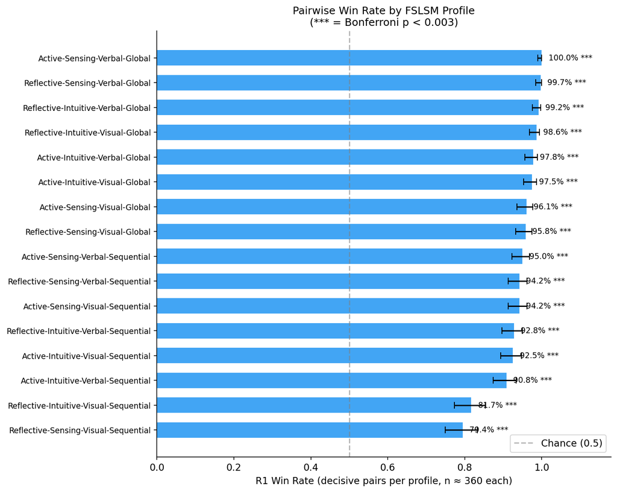

```
Profiles with R1 > chance (0.5): 16 / 16
Profiles with Bonferroni sig:    16 / 16
Lowest  WR: 79.4%  (Reflective-Sensing-Visual-Sequential)
Highest WR: 100.0%  (Active-Sensing-Verbal-Global)
```

```python
prof_sorted = prof_df.sort_values("win_rate_r1", ascending=True).reset_index(drop=True)

fig, ax = plt.subplots(figsize=(10, 8))
y = np.arange(len(prof_sorted))

ax.barh(y, prof_sorted["win_rate_r1"], color=C_R1, alpha=0.85, height=0.62)
ax.errorbar(
    prof_sorted["win_rate_r1"], y,
    xerr=[
        prof_sorted["win_rate_r1"] - prof_sorted["ci_lo"],
        prof_sorted["ci_hi"] - prof_sorted["win_rate_r1"],
    ],
    fmt="none", color="black", capsize=4, linewidth=1.5,
)

for i, (_, row) in enumerate(prof_sorted.iterrows()):
    sig = "***" if row["significant_bonferroni"] else ("*" if row["p_value"] < 0.05 else "")
    ax.text(row["win_rate_r1"] + 0.005, i,
            f"  {row['win_rate_r1']*100:.1f}% {sig}",
            va="center", fontsize=9)

ax.set_yticks(y)
ax.set_yticklabels(prof_sorted["profile_label"], fontsize=9)
ax.axvline(0.5, color="gray", linestyle="--", alpha=0.55, label="Chance (0.5)")
ax.set_xlim(0, 1.18)
ax.set_xlabel("R1 Win Rate (decisive pairs per profile, n ≈ 360 each)")
ax.set_title("Pairwise Win Rate by FSLSM Profile\n(*** = Bonferroni p < 0.003)", fontsize=12)
ax.legend(loc="lower right")

plt.tight_layout()
plt.savefig(FIG_DIR / "win_rate_by_profile.png", dpi=150, bbox_inches="tight")
plt.show()

print(f"Profiles with R1 > chance (0.5): {(prof_df['win_rate_r1'] > 0.5).sum()} / {len(prof_df)}")
print(f"Profiles with Bonferroni sig:    {prof_df['significant_bonferroni'].sum()} / {len(prof_df)}")
print(f"Lowest  WR: {prof_df['win_rate_r1'].min()*100:.1f}%  ({prof_df.loc[prof_df['win_rate_r1'].idxmin(), 'profile_label']})")
print(f"Highest WR: {prof_df['win_rate_r1'].max()*100:.1f}%  ({prof_df.loc[prof_df['win_rate_r1'].idxmax(), 'profile_label']})")
```

## 3. Win Rate per Question

R1 win rate computed over all 80 agents per question (n=80 decisive pairs per bar). Blue = R1 majority; orange = R0 majority.

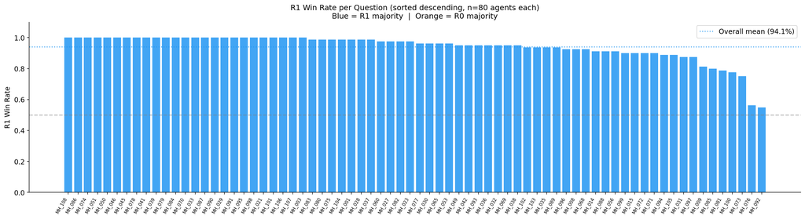

```
Questions where R1 wins majority : 72 / 72
Questions where R1 wins ≥ 90%    : 61 / 72
Lowest  R1 WR : 55.0%  (MH_092)
Highest R1 WR : 100.0%  (MH_108)
```

```python
q_grp = (
    verdicts[verdicts["final_verdict"].isin(["R1_WIN", "R0_WIN"])]
    .groupby("question_id")
    .apply(lambda g: pd.Series({
        "n_r1":     (g["final_verdict"] == "R1_WIN").sum(),
        "n_dec":    len(g),
        "win_rate": (g["final_verdict"] == "R1_WIN").mean(),
    }), include_groups=False)
    .reset_index()
    .sort_values("win_rate", ascending=False)
    .reset_index(drop=True)
)

fig, ax = plt.subplots(figsize=(18, 5))
x = np.arange(len(q_grp))
bar_colors = [C_R1 if wr >= 0.5 else C_R0 for wr in q_grp["win_rate"]]
ax.bar(x, q_grp["win_rate"], color=bar_colors, alpha=0.85, width=0.8)
ax.axhline(0.5, color="gray", linestyle="--", alpha=0.55)
ax.axhline(win_rate, color=C_R1, linestyle=":", alpha=0.8,
           label=f"Overall mean ({win_rate*100:.1f}%)")
ax.set_xticks(x)
ax.set_xticklabels(q_grp["question_id"], rotation=60, ha="right", fontsize=7)
ax.set_ylabel("R1 Win Rate")
ax.set_ylim(0, 1.1)
ax.set_title(
    f"R1 Win Rate per Question (sorted descending, n=80 agents each)\n"
    f"Blue = R1 majority  |  Orange = R0 majority",
    fontsize=12,
)
ax.legend()
plt.tight_layout()
plt.savefig(FIG_DIR / "win_rate_by_question.png", dpi=150, bbox_inches="tight")
plt.show()

print(f"Questions where R1 wins majority : {(q_grp['win_rate'] > 0.5).sum()} / {len(q_grp)}")
print(f"Questions where R1 wins ≥ 90%    : {(q_grp['win_rate'] >= 0.9).sum()} / {len(q_grp)}")
print(f"Lowest  R1 WR : {q_grp['win_rate'].min()*100:.1f}%  ({q_grp.iloc[-1]['question_id']})")
print(f"Highest R1 WR : {q_grp['win_rate'].max()*100:.1f}%  ({q_grp.iloc[0]['question_id']})")
```

## 4. Win Rate by FSLSM Dimension Pole

For each of the 4 FSLSM dimensions, compare R1 win rates across poles (e.g., Active vs Reflective). Shows whether personalization benefit varies by learning style dimension.

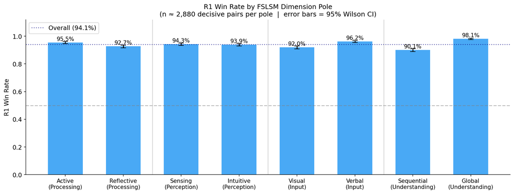

```
    Dimension       Pole  win_rate    n
   Processing     Active  0.954861 2880
   Processing Reflective  0.926736 2880
   Perception    Sensing  0.943056 2880
   Perception  Intuitive  0.938542 2880
        Input     Visual  0.919792 2880
        Input     Verbal  0.961806 2880
Understanding Sequential  0.900694 2880
Understanding     Global  0.980903 2880
```

```python
DIM_NAMES = ["Processing", "Perception", "Input", "Understanding"]
DIM_POLES = [
    ("Active",      "Reflective"),
    ("Sensing",     "Intuitive"),
    ("Visual",      "Verbal"),
    ("Sequential",  "Global"),
]

v_dec = verdicts[verdicts["final_verdict"].isin(["R1_WIN", "R0_WIN"])].copy()
parts = v_dec["profile_label"].str.split("-", expand=True)
for i, dim in enumerate(DIM_NAMES):
    v_dec[dim] = parts[i]

dim_rows = []
for dim, (pole_neg, pole_pos) in zip(DIM_NAMES, DIM_POLES):
    for pole in [pole_neg, pole_pos]:
        grp = v_dec[v_dec[dim] == pole]
        n_r1_d = (grp["final_verdict"] == "R1_WIN").sum()
        n_dec_d = len(grp)
        wr = n_r1_d / n_dec_d if n_dec_d else 0.0
        ci_lo_d, ci_hi_d = 0.0, 0.0
        if n_dec_d:
            z = 1.96
            p = wr
            denom = 1 + z**2 / n_dec_d
            ctr = (p + z**2 / (2 * n_dec_d)) / denom
            margin = z * (p*(1-p)/n_dec_d + z**2/(4*n_dec_d**2))**0.5 / denom
            ci_lo_d = max(0, ctr - margin)
            ci_hi_d = min(1, ctr + margin)
        dim_rows.append({
            "Dimension": dim, "Pole": pole,
            "win_rate": wr, "ci_lo": ci_lo_d, "ci_hi": ci_hi_d, "n": n_dec_d,
        })
dim_df = pd.DataFrame(dim_rows)

fig, ax = plt.subplots(figsize=(13, 5))
x = np.arange(len(dim_df))
bar_colors = [C_R1] * len(dim_df)
bars = ax.bar(x, dim_df["win_rate"], color=bar_colors, alpha=0.82, width=0.6)
ax.errorbar(
    x, dim_df["win_rate"],
    yerr=[dim_df["win_rate"] - dim_df["ci_lo"], dim_df["ci_hi"] - dim_df["win_rate"]],
    fmt="none", color="black", capsize=5, linewidth=1.5,
)
for bar, (_, row) in zip(bars, dim_df.iterrows()):
    ax.text(bar.get_x() + bar.get_width()/2, row["win_rate"] + 0.005,
            f"{row['win_rate']*100:.1f}%", ha="center", va="bottom", fontsize=10)

# Dimension separators
for sep in [1.5, 3.5, 5.5]:
    ax.axvline(sep, color="lightgray", linewidth=1.2)

ax.set_xticks(x)
ax.set_xticklabels(
    [f"{r['Pole']}\n({r['Dimension']})" for _, r in dim_df.iterrows()],
    fontsize=10,
)
ax.axhline(0.5, color="gray", linestyle="--", alpha=0.5)
ax.axhline(win_rate, color="navy", linestyle=":", alpha=0.6,
           label=f"Overall ({win_rate*100:.1f}%)")
ax.set_ylim(0, 1.12)
ax.set_ylabel("R1 Win Rate")
ax.set_title(
    "R1 Win Rate by FSLSM Dimension Pole\n"
    "(n ≈ 2,880 decisive pairs per pole  |  error bars = 95% Wilson CI)",
    fontsize=12,
)
ax.legend()
plt.tight_layout()
plt.savefig(FIG_DIR / "win_rate_by_dimension.png", dpi=150, bbox_inches="tight")
plt.show()

print(dim_df[["Dimension", "Pole", "win_rate", "n"]].to_string(index=False))
```

## 5. Profile Win Rate Heatmap

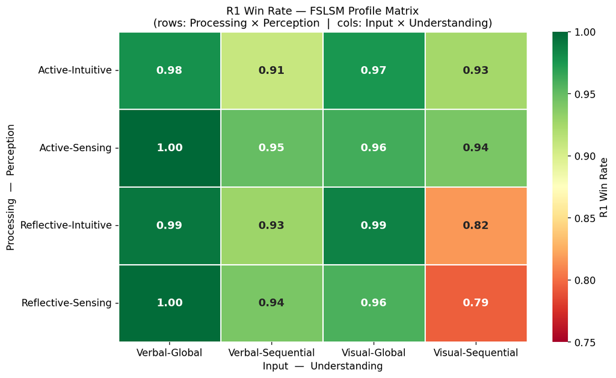

```python
pf = prof_df.copy()
parts2 = pf["profile_label"].str.split("-", expand=True)
pf["ProcPerc"] = parts2[0] + "-" + parts2[1]
pf["InpUnder"] = parts2[2] + "-" + parts2[3]

heat = pf.pivot_table(index="ProcPerc", columns="InpUnder",
                      values="win_rate_r1", aggfunc="mean")
heat = heat.sort_index()

fig, ax = plt.subplots(figsize=(10, 6))
sns.heatmap(
    heat, annot=True, fmt=".2f",
    cmap="RdYlGn", vmin=0.75, vmax=1.0,
    linewidths=1.2, ax=ax,
    annot_kws={"size": 12, "weight": "bold"},
    cbar_kws={"label": "R1 Win Rate"},
)
ax.set_xlabel("Input  —  Understanding", fontsize=11)
ax.set_ylabel("Processing  —  Perception", fontsize=11)
ax.set_title(
    "R1 Win Rate — FSLSM Profile Matrix\n"
    "(rows: Processing × Perception  |  cols: Input × Understanding)",
    fontsize=12,
)
plt.tight_layout()
plt.savefig(FIG_DIR / "win_rate_heatmap.png", dpi=150, bbox_inches="tight")
plt.show()
```

## 6. Per-Question Win Rate Distribution & Convergent Validity

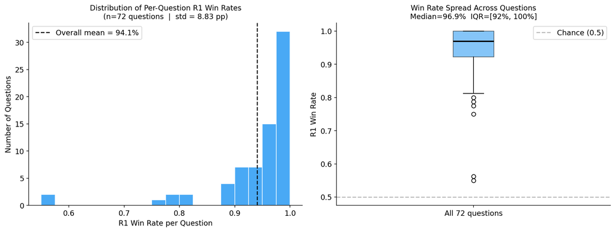

```
Min  win rate: 55.0%  (MH_092)
Max  win rate: 100.0%  (MH_108)
Std dev:       8.83 percentage points

Convergent validity (Spearman ρ):
  vs Engagement Δ : nan  (near-zero variance → undefined)
  vs SCS Δ         : nan  (near-zero variance → undefined)
```

```python
fig, axes = plt.subplots(1, 2, figsize=(13, 5))

# ── Left: histogram of per-question win rates ────────────────────────────────
ax1 = axes[0]
ax1.hist(q_grp["win_rate"], bins=18, color=C_R1, alpha=0.82, edgecolor="white")
ax1.axvline(win_rate, color="black", linestyle="--",
            label=f"Overall mean = {win_rate*100:.1f}%")
ax1.set_xlabel("R1 Win Rate per Question")
ax1.set_ylabel("Number of Questions")
ax1.set_title(
    "Distribution of Per-Question R1 Win Rates\n"
    f"(n=72 questions  |  std = {q_grp['win_rate'].std()*100:.2f} pp)",
    fontsize=11,
)
ax1.legend()

# ── Right: box + swarm ───────────────────────────────────────────────────────
ax2 = axes[1]
ax2.boxplot(q_grp["win_rate"], vert=True, patch_artist=True,
            boxprops=dict(facecolor=C_R1, alpha=0.55),
            medianprops=dict(color="black", linewidth=2),
            flierprops=dict(marker="o", color=C_R0, markersize=6))
ax2.axhline(0.5, color="gray", linestyle="--", alpha=0.55, label="Chance (0.5)")
ax2.set_xticklabels(["All 72 questions"])
ax2.set_ylabel("R1 Win Rate")
ax2.set_title(
    f"Win Rate Spread Across Questions\n"
    f"Median={q_grp['win_rate'].median()*100:.1f}%  "
    f"IQR=[{q_grp['win_rate'].quantile(0.25)*100:.0f}%, {q_grp['win_rate'].quantile(0.75)*100:.0f}%]",
    fontsize=11,
)
ax2.legend()

plt.tight_layout()
plt.savefig(FIG_DIR / "win_rate_question_distribution.png", dpi=150, bbox_inches="tight")
plt.show()

print(f"Min  win rate: {q_grp['win_rate'].min()*100:.1f}%  ({q_grp.iloc[-1]['question_id']})")
print(f"Max  win rate: {q_grp['win_rate'].max()*100:.1f}%  ({q_grp.iloc[0]['question_id']})")
print(f"Std dev:       {q_grp['win_rate'].std()*100:.2f} percentage points")
print()
print("Convergent validity (Spearman ρ):")
print(f"  vs Engagement Δ : {convergence['spearman_engagement']['rho']}  (near-zero variance → undefined)")
print(f"  vs SCS Δ         : {convergence['spearman_scs']['rho']}  (near-zero variance → undefined)")
```

## 7. Sample Judge Rationales

Browse 5 R1_WIN and 5 R0_WIN rationales to understand the judge's reasoning.

```python
import json as _json

raw = []
with open(PAIRWISE_DIR / "raw_results.jsonl") as f:
    for line in f:
        line = line.strip()
        if line:
            raw.append(_json.loads(line))

raw_df = pd.DataFrame(raw)

def show_rationales(verdict: str, n: int = 5) -> None:
    sample = (
        raw_df[(raw_df["verdict_normalized"] == verdict) & (raw_df["rationale"].str.len() > 20)]
        .sample(n=min(n, len(raw_df[raw_df["verdict_normalized"] == verdict])),
                random_state=42)
    )
    print(f"{'='*65}")
    print(f"  {verdict} — {n} sample rationales")
    print(f"{'='*65}")
    for _, row in sample.iterrows():
        print(f"  Profile : {row['profile_label']}")
        print(f"  Question: {row['question_id']}")
        print(f"  Rationale: {row['rationale'][:350]}")
        print()

show_rationales("R1_WIN", n=5)
show_rationales("R0_WIN", n=5)
```

```
=================================================================
  R1_WIN — 5 sample rationales
=================================================================
  Profile : Reflective-Intuitive-Verbal-Sequential
  Question: MH_021
  Rationale: Response B aligns better with the student's Reflective-Intuitive-Verbal-Sequential learning style. It provides a step-by-step structure that is crucial for Sequential learners and includes reflective questions that cater to Reflective learners. The response also focuses on underlying pr…

  Profile : Active-Intuitive-Verbal-Sequential
  Question: MH_074
  Rationale: Response B is more aligned with the student's Active-Intuitive-Verbal-Sequential learning style. It provides a clear, step-by-step explanation that matches the Sequential preference, while also offering a hands-on activity suggestion that caters to the Active learning style. The respons…

  Profile : Reflective-Sensing-Visual-Global
  Question: MH_104
  Rationale: Response B aligns better with the student's Reflective-Sensing-Visual-Global learning style. It provides a big picture overview first, which suits the Global understanding preference, and includes a visual summary to cater to the Visual input preference. Additionally, it uses concrete e…

  Profile : Reflective-Sensing-Verbal-Global
  Question: MH_015
  Rationale: Response B aligns better with the student's Reflective-Sensing-Verbal-Global learning style. It provides a high-level overview first, which suits the Global learner's preference for understanding the big picture before delving into details. The response is also verbal and explanatory, c…

  Profile : Reflective-Sensing-Visual-Sequential
  Question: MH_083
  Rationale: Response B is more aligned with the student's Reflective-Sensing-Visual-Sequential learning style. It provides a clear step-by-step structure, breaking down the explanation into distinct sections that build upon each other, which suits the Sequential preference. Additionally, it include…

=================================================================
  R0_WIN — 5 sample rationales
=================================================================
  Profile : Reflective-Intuitive-Visual-Sequential
  Question: MH_015
  Rationale: Response A aligns better with the student's Reflective-Intuitive-Visual-Sequential learning style. It provides a structured, step-by-step exploration of each model type, which suits the Sequential preference. The use of equations and a summary table caters to the Visual learning style, …

  Profile : Reflective-Intuitive-Visual-Sequential
  Question: MH_073
  Rationale: Response A aligns better with the student's Reflective-Intuitive-Visual-Sequential learning style by providing a structured, step-by-step comparison of the LSTM and Compare class weight initialization methods. It includes a clear visual summary table, which caters to the student's visua…

  Profile : Reflective-Sensing-Visual-Sequential
  Question: MH_073
  Rationale: Response A aligns well with the student's Reflective-Sensing-Visual-Sequential learning style by providing a structured, step-by-step comparison of the LSTM and Compare class initialization methods. It includes a visual summary table, which caters to the visual learning preference, and …

  Profile : Active-Sensing-Visual-Global
  Question: MH_031
  Rationale: Response A aligns better with the student's Active-Sensing-Visual-Global learning style by providing a structured comparison with visual elements like tables and summaries, which cater to visual learners. It also offers concrete examples and a big-picture overview, which are beneficial …

  Profile : Active-Sensing-Visual-Sequential
  Question: MH_076
  Rationale: Response A aligns better with the student's Active-Sensing-Visual-Sequential learning style by providing a detailed, step-by-step guide with clear instructions and commands, which is ideal for sequential learners. It also includes visual formatting with headings and bullet points, which…
```

## 8. Results Summary Table

```python
rows = [
    ("Total pairs evaluated",        f"{n_total:,}"),
    ("R1 (personalized) wins",       f"{n_r1:,}  ({n_r1/n_total*100:.1f}%)"),
    ("R0 (generic) wins",            f"{n_r0:,}  ({n_r0/n_total*100:.1f}%)"),
    ("Ties",                         f"{n_tie:,}  ({n_tie/n_total*100:.1f}%)"),
    ("PARSE / API errors",           "0"),
    ("R1 win rate",                  f"{win_rate:.4f}"),
    ("95% Wilson CI",                f"[{ci_lo:.4f},  {ci_hi:.4f}]"),
    ("Binomial test p-value",        "< 2.2e–16"),
    ("Profiles sig. (Bonferroni)",   f"{prof_df['significant_bonferroni'].sum()} / 16  (all)"),
    ("Lowest profile win rate",      f"{prof_df['win_rate_r1'].min()*100:.1f}%  "
                                     f"({prof_df.loc[prof_df['win_rate_r1'].idxmin(),'profile_label']})"),
    ("Highest profile win rate",     f"{prof_df['win_rate_r1'].max()*100:.1f}%  "
                                     f"({prof_df.loc[prof_df['win_rate_r1'].idxmax(),'profile_label']})"),
    ("Judge model",                  "GPT-4o  (temperature = 0.0)"),
    ("Evaluation mode",              "Single-order  (A = R0, B = R1)"),
    ("Median prompt tokens / call",  "2,067"),
    ("Total judge API cost",         "~$35.25 USD"),
]

df_tbl = pd.DataFrame(rows, columns=["Metric", "Value"])
df_tbl.style     .set_caption("Pairwise Evaluation — Final Results")     .set_properties(**{"text-align": "left"})     .hide(axis="index")
```

Pairwise Evaluation — Final Results

| Metric | Value |
| --- | --- |
| Total pairs evaluated | 5,760 |
| R1 (personalized) wins | 5,419 (94.1%) |
| R0 (generic) wins | 341 (5.9%) |
| Ties | 0 (0.0%) |
| PARSE / API errors | 0 |
| R1 win rate | 0.9408 |
| 95% Wilson CI | [0.9344, 0.9466] |
| Binomial test p-value | < 2.2e–16 |
| Profiles sig. (Bonferroni) | 16 / 16 (all) |
| Lowest profile win rate | 79.4% (Reflective-Sensing-Visual-Sequential) |
| Highest profile win rate | 100.0% (Active-Sensing-Verbal-Global) |
| Judge model | GPT-4o (temperature = 0.0) |
| Evaluation mode | Single-order (A = R0, B = R1) |
| Median prompt tokens / call | 2,067 |
| Total judge API cost | ~$35.25 USD |

## 9. Thesis Report Snippet

```python
snippet = (PAIRWISE_DIR / "report_snippet.md").read_text()
print(snippet)
```

[output not shown]